# Homework 08

The former kernel-tuning question has moved to Homework 09.

Solutions for Questions 1 and 2 will be available after Monday, October 19, 2026. No solution can be provided for Question 3.

For Questions 1 and 2, use either R or Python.

## Question 1: Boundary and margin

Use `margin-geometry-20.csv` from the combined ZIP, which contains 20 observations with predictors $x_1,x_2$ and class labels $y\in\{-1,1\}$. Consider the score

$$f(x)=0.8x_1+0.6x_2.$$

Since $\|(0.8,0.6)\|_2=1$, the lines $f(x)=\pm1$ are each a distance 1 from the decision boundary $f(x)=0$.

1. Calculate the distance from every observation to the decision boundary and its functional margin $yf(x)$. In a table, report these values and whether each observation is inside, on, or beyond the margin for its class. Compare $yf(x)$ with 1 to make this distinction.

```python
import pandas as pd
import numpy as np
import matplotlib.pyplot as plt

df = pd.read_csv("data/margin-geometry-20.csv")

# Calculate decision score
df["score"] = 0.8 * df["x1"] + 0.6 * df["x2"]

# Distance to boundary
df["distance"] = abs(df["score"])

# Functional margin
df["functional_margin"] = df["y"] * df["score"]

# Classify margin status
df["margin_status"] = np.select(
    [
        df["functional_margin"] < 1 - 1e-9,
        np.isclose(df["functional_margin"], 1)
    ],
    ["Inside", "On"],
    default="Beyond"
)

print(df.to_string(index=False))
```

```
 observation    x1    x2  y  score  distance  functional_margin margin_status
           1  0.68  0.76  1   1.00      1.00               1.00            On
           2  1.80 -0.15  1   1.35      1.35               1.35        Beyond
           3  1.38  0.66  1   1.50      1.50               1.50        Beyond
           4  0.88  1.66  1   1.70      1.70               1.70        Beyond
           5  0.62  2.34  1   1.90      1.90               1.90        Beyond
           6  2.78 -0.04  1   2.20      2.20               2.20        Beyond
           7  1.86  1.52  1   2.40      2.40               2.40        Beyond
           8  0.50  0.40  1   0.64      0.64               0.64        Inside
           9  0.10  0.20  1   0.20      0.20               0.20        Inside
          10 -0.40  0.20  1  -0.20      0.20              -0.20        Inside
          11 -0.92 -0.44 -1  -1.00      1.00               1.00            On
          12 -0.50 -1.50 -1  -1.30      1.30               1.30        Beyond
          13 -1.90 -0.05 -1  -1.55      1.55               1.55        Beyond
          14 -0.44 -2.33 -1  -1.75      1.75               1.75        Beyond
          15 -1.98 -0.61 -1  -1.95      1.95               1.95        Beyond
          16 -2.74  0.07 -1  -2.15      2.15               2.15        Beyond
          17 -1.90 -1.55 -1  -2.45      2.45               2.45        Beyond
          18 -0.50 -0.40 -1  -0.64      0.64               0.64        Inside
          19  0.00 -0.40 -1  -0.24      0.24               0.24        Inside
          20  0.40 -0.20 -1   0.20      0.20              -0.20        Inside
```

2. Plot the observations, the boundary $f(x)=0$, and the margin lines $f(x)=\pm1$. Distinguish the two classes and identify the observations inside the margin in your plot.

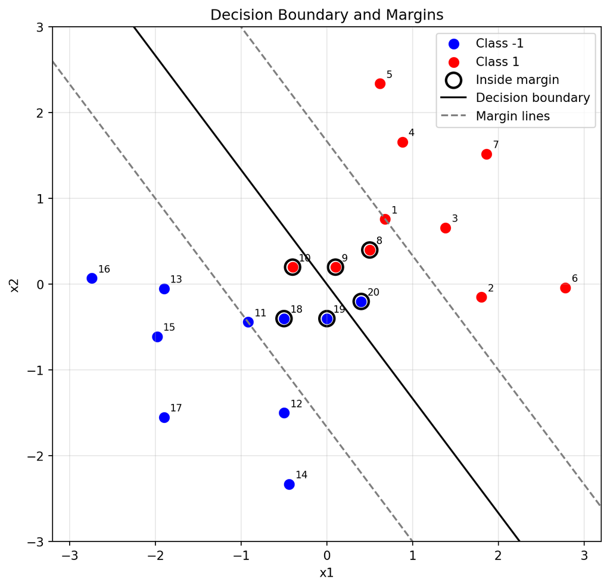

```python
x = np.linspace(-3.2, 3.2, 200)

plt.figure(figsize=(8, 8))

# Plot observations by class
for y, color in [(-1, "blue"), (1, "red")]:
    subset = df[df["y"] == y]
    plt.scatter(
        subset["x1"], subset["x2"],
        color=color, label=f"Class {y}", s=60
    )

# Highlight points inside the margin
inside = df[df["margin_status"] == "Inside"]

plt.scatter(
    inside["x1"], inside["x2"],
    facecolors="none", edgecolors="black",
    s=150, linewidths=2, label="Inside margin"
)

# Decision boundary and margins
plt.plot(x, -0.8*x/0.6,
         color="black", label="Decision boundary")

plt.plot(x, (1-0.8*x)/0.6,
         color="gray", linestyle="--", label="Margin lines")

plt.plot(x, (-1-0.8*x)/0.6,
         color="gray", linestyle="--")

# Label each observation using its ID
id_col = "observation" if "observation" in df.columns else "id"

for _, row in df.iterrows():
    plt.annotate(
        str(row[id_col]),
        (row["x1"], row["x2"]),
        xytext=(5, 5),
        textcoords="offset points",
        fontsize=8
    )

plt.xlim(-3.2, 3.2)
plt.ylim(-3, 3)
plt.gca().set_aspect("equal")

plt.xlabel("x1")
plt.ylabel("x2")
plt.title("Decision Boundary and Margins")
plt.legend()
plt.grid(alpha=0.3)
plt.show()
```

3. Report how many observations are inside, on, and beyond the margin. Which observations are misclassified by this decision rule?

```python
print("Margin counts:")
print(df["margin_status"].value_counts())

misclassified = df[df["functional_margin"] < 0]

print("\nMisclassified observations:")
print(misclassified[[id_col, "y", "score", "functional_margin"]])
```

```
Margin counts:
margin_status
Beyond    12
Inside     6
On         2
Name: count, dtype: int64

Misclassified observations:
    observation  y  score  functional_margin
9            10  1   -0.2               -0.2
19           20 -1    0.2               -0.2
```

Use the observation numbers supplied in the data. Set the $x_1$ axis to $[-3.2,3.2]$, set the $x_2$ axis to $[-3,3]$, and use an equal aspect ratio. Do not fit a new classifier for this question.

## Question 2: Margin in four dimensions

Use `margin-geometry-4d.csv` from the combined ZIP, which contains 50 observations with four predictors and class labels $y\in\{-1,1\}$. Consider the linear score

$$f(\mathbf{x})=\beta_0+\mathbf{x}^{\mathsf T}\boldsymbol{\beta},
\qquad
\beta_0=-1,
\quad
\boldsymbol{\beta}=(1,2,-2,4)^{\mathsf T}.$$

1. Project the observations onto the direction of $\boldsymbol{\beta}$ and plot their positions on one axis. Distinguish the two classes and mark the decision boundary. Use the plot to calculate the geometric margin $M$, the distance from the boundary to the closest observation.

```
Beta norm: 5.0
Decision boundary: 0.2
Geometric margin M: 1.0
```

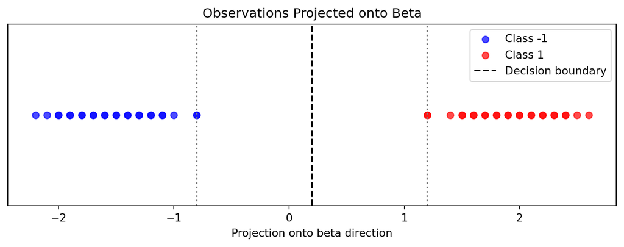

```python
df4 = pd.read_csv("data/margin-geometry-4d.csv")

beta = np.array([1, 2, -2, 4])
beta0 = -1

X = df4[["x1", "x2", "x3", "x4"]].to_numpy()

# Project observations onto beta direction
beta_norm = np.linalg.norm(beta)
df4["projection"] = X @ beta / beta_norm

# Boundary in projected coordinates
boundary = -beta0 / beta_norm

# Geometric distance to boundary
df4["distance"] = abs(df4["projection"] - boundary)

M = df4["distance"].min()

print("Beta norm:", beta_norm)
print("Decision boundary:", boundary)
print("Geometric margin M:", M)

# Plot projected observations
plt.figure(figsize=(10, 3))

for y, color in [(-1, "blue"), (1, "red")]:
    subset = df4[df4["y"] == y]

    plt.scatter(
        subset["projection"],
        np.zeros(len(subset)),
        color=color,
        label=f"Class {y}",
        alpha=0.7
    )

plt.axvline(
    boundary, color="black",
    linestyle="--", label="Decision boundary"
)

plt.axvline(boundary - M, color="gray", linestyle=":")
plt.axvline(boundary + M, color="gray", linestyle=":")

plt.yticks([])
plt.xlabel("Projection onto beta direction")
plt.title("Observations Projected onto Beta")
plt.legend()
plt.show()
```

2. Express the same decision boundary using the SVM normalization in which the smallest functional margin $y_i f(\mathbf{x}_i)$ is set to 1. What are the corresponding values of $\boldsymbol{\beta}$ and $\beta_0$?

```python
# Original linear scores
scores = beta0 + X @ beta

# Functional margins
functional_margins = df4["y"].to_numpy() * scores
min_margin = functional_margins.min()

print("Minimum functional margin:", min_margin)

if min_margin > 0:
    beta_new = beta / min_margin
    beta0_new = beta0 / min_margin

    print("Normalized beta:", beta_new)
    print("Normalized intercept:", beta0_new)
    print(
        "New minimum functional margin:",
        (functional_margins / min_margin).min()
    )
else:
    print("The given score cannot be SVM-normalized")
    print("to all functional margins >= 1 by positive scaling.")
```

```
Minimum functional margin: 5.0
Normalized beta: [ 0.2  0.4 -0.4  0.8]
Normalized intercept: -0.2
New minimum functional margin: 1.0
```

## Question 3: Peer review of a Homework 7 skill

The instructor’s GitHub account, **rqzhu-aide**, will open a **GitHub Issue** in the repository containing your Homework 7 submission. It will link to **one** assigned student’s repository.

1. **Use the skill.** Find the complete skill definition in the assigned student’s Homework 7 report. Copy it without changes into a local `SKILL.md` file in your own folder. You do not need to install it. Give your agent the path to the file and explicitly ask it to follow that skill while analyzing the `SAheart` data, using the response and predictor coding from Homework 7. Provide the necessary data information, but no additional preferences about methods, figures, model selection, or report style. Let the skill direct the analysis.

   Monitor the time, your token use, and your weekly quota while the agent works. If the run is taking too long or using your allowance too quickly, you may send a **steer message** asking the agent to finish immediately, or stop the run and summarize what you observed. A steer message redirects an agent while it is working; learn how to send one in your AI tool before starting.

I copied the student’s skill into a local `SKILL.md` file and used GitHub Copilot to run it on the SAheart dataset, with `chd` as the response and all nine other variables as predictors. I coded `famhist` as 1 for Absent and 2 for Present. I followed the skill without adding any additional preferences for the analysis.

Copilot successfully completed the analysis and generated `saheart-lda-qda-report.md` and `saheart-cv-errors.png`.

The analysis used a stratified 70/30 training and test split with seed 2026 and stratified 10-fold cross-validation. The selected model was ordinary LDA, with a cross-validation error of 0.2842 and a test error of 0.2662.

2. **Write a peer review.** Read the student’s submitted report and what the skill produced in your run. Give a brief overall assessment, followed by **three major items the author could improve**. You may comment on any aspect of the skill or report. For each item, explain what you observed, why it matters, and what you recommend changing. If you stopped the run early, explain where and why. Write the review yourself, without AI assistance.

Overall, I think your skill worked well. Copilot was able to follow the instructions and create a complete report with model comparisons, a figure, and a confusion matrix. Both runs also selected ordinary LDA, which was good to see. However, I think there are three things that could be improved. First, using a consistent random seed would make the results easier to reproduce. Second, the report could be more careful when saying models are statistically indistinguishable, since the one-standard-error rule doesn’t necessarily mean that. Lastly, I think including sensitivity and specificity would be helpful in showing how well the model predicts patients with and without heart disease.

3. **Share your review.** Open a GitHub Issue in the assigned student’s Homework 7 repository containing your review. Copy the same review into your Homework 8 submission report and include a link to the GitHub Issue.

https://github.com/stallur10/stat432-fall2026/issues/5